# Graphiques

```python
# import NumPy
import numpy as np
# import the matplotlib plotting functionality
import pylab as plt
```

```python
# If you use the IPython notebook :
# this line tell IPython to plot figures
# directly in the notebook, not in a separate figure
%matplotlib inline
```

At the contrary to languages like Matlab or IDL, the support of plotting capabilities is not built-in in Python and requires an external library.

The workhorse for scientific plotting in Python is matplotlib.

The matplotlib library has been built in order to be close to the Matlab commands, and most of the command are the same.

```python
from numpy import *
```

```python
pi
```

```
3.141592653589793
```

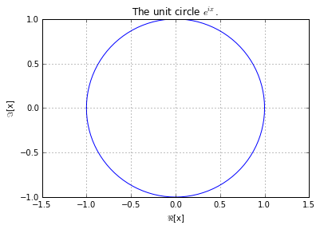

```python
x = np.linspace(-np.pi, np.pi, 101)
y = np.exp(-1j*x)

plt.plot(np.real(y), np.imag(y))
plt.axis('equal')
plt.xlabel('$\Re$[x]')
plt.ylabel('$\Im$[x]')
plt.grid(True) # or grid('on') like in Matlab
plt.title('The unit circle $e^{i x}$.')
```

```python
from pylab import *
```

## Pylab mode

Typing plt. and np. can be cumbersome... (but is recommanded for code which are more than just snippets) To alleviate, one can import most of the matplotlib, numpy and scipy libraries into the interpreter namespace :

```
from pylab import *
```

(ou, dans un terminal IPython en mode interactif:

```
%pylab
```

**But beware**! Doing like that, you don't know exactly what you've imported (and eventually overwritten) in the memory !

Example: which sum() are we now using: the Python native sum() which takes Python list or the NumPy version which takes NumPy array? Same for min() or max().

```python
# In IPython :
%pylab
%matplotlib inline
```

```
Using matplotlib backend: TkAgg
```

```
WARNING: pylab import has clobbered these variables: ['power', 'draw_if_interactive', 'linalg', 'fft', 'info', 'random']
`%matplotlib` prevents importing * from pylab and numpy
```

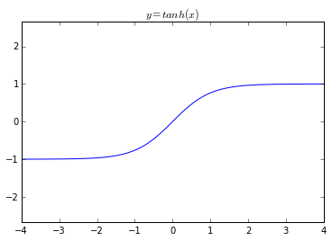

```python
# The code below very much looks like matlab !
x = linspace(-4, 4, 101)
y = tanh(x)
plot(x,y)
axis('equal')
title('$y=tanh(x)$')
```

## Commandes et options de Matplotlib

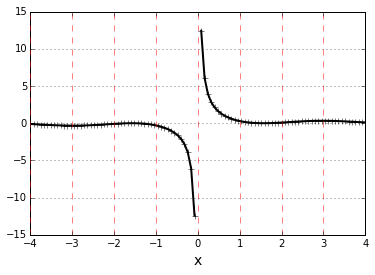

```python
# As in matlab, the line properties can be ajusted,
# either graphically using the GUI (for independant plots)
# or with commands
plot(x, cos(x)**2 /x, linewidth=2, color='k', marker='+')
grid(axis='y')
grid(axis='x', color='r', linestyle='--')
xlabel('x', fontsize=14)
```

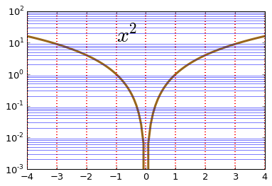

```python
plot(x, x**2, color=(0.6, 0.4, 0.1), lw=3)
yscale('log')
grid(which='minor', color='b', axis='both', linestyle='-')
grid(which='major', color='r', axis='x', linewidth=2 )
xticks(fontsize=13)
yticks(fontsize=13)
text(-1, 10, '$x^2$', fontsize=30)
```

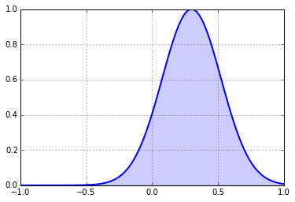

```python
x = linspace(-1, 1, 101)
y = exp(-(x - 0.3)**2 / 0.1)
plot(x, y, lw=2)
fill_between(x, y, alpha=0.2)
axis([-1, 1, 0, 1], 'equal')
grid()
```

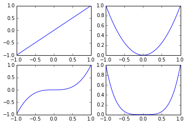

```python
subplot(221)
plot(x, x**1)
subplot(222)
plot(x, x**2)
subplot(223)
plot(x, x**3)
subplot(224)
plot(x, x**4)
```

## How to make ... ?

Matplotlib is now a very mature library, which allows users to perform many kind of different graphics type.

Please have a look the Matplotlib Gallery to discover the various possibilities!

```python
from IPython import utils
from IPython.core.display import HTML
import os
def css_styling():
    """Load the CSS sheet 'custom.css' located in the directory"""
    styles = "<style>\n%s\n</style>" % (open('./custom.css','r').read())
    return HTML(styles)
css_styling()
```